# 15-minute City in Moscow

Measuring Pedestrian Accessibility to Everyday Services

Anna Lvova

##Intro

A 15-minute city is a concept gaining popularity around the globe that focuses of urban to sustainability. It has been already adopted as part of long-term strategies in Paris, Portland, Melbourne and others. A 15-minute city is one where everything people need including food, medicine, housing, jobs, education and entertainment is close to them.

This research aims to evaluate accessibility to everyday services for Moscow residents. We use open data about commercial and public amenities in Moscow and perform service area analysis. The goal of this analysis is to address spatial inequalities and sustainable development issues to the local policy makers.

## Data collection and wrangling

```r
library(sf)
library(sp)
library(readxl)
library(tidyverse)
library(tmap)
library(tmaptools)
library(rgdal)
library(mapview)
library(ggplot2)
library(ggthemes)
library(mapboxapi)
library(spatstat)
library(httr)
library(pins)
library(XML)
library(methods)
library(purrr)
library(ggmap)
library (reshape2)
library(plotly)
```

#### Amenities

First, we collect location data for 5 types of amenities in Moscow:

- grocery stores,
- parks,
- schools,
- public medical centers,
- sport facilities.

Grocery stores data was additionally cleaned from non-food stores. Only chain stores were left as non-chain stores in Moscow are often of lower quality and stock.

```r
download.file("https://op.mos.ru/EHDWSREST/catalog/export/get?id=1034392",
              destfile = "data/groceries.zip")
unzip("data/groceries.zip", exdir="data")

groceries_source <- read_excel("data/data-28509-2021-01-24.xlsx",
                                na = "")

groceries <- groceries_source %>%
  dplyr::filter(TypeService == "реализация продовольственных товаров") %>%
  dplyr::filter(TypeObject!="Магазин «Алкогольные напитки»") %>%
  dplyr::filter(IsNetObject == "да") %>%
  dplyr::select(ID, Name,Address,IsNetObject,TypeObject,geoData) %>%
  rowwise() %>%
  mutate(
    coord = strsplit(geoData, "coordinates=[", fixed=TRUE)[[1]][2],
    lon = strsplit(coord, ", ", fixed=TRUE)[[1]][1],
    lat = strsplit(coord, ", ", fixed=TRUE)[[1]][2],
    lat = strsplit(lat, "]}", fixed=TRUE)[[1]][1]
    ) %>%
  dplyr::select(ID, Name,Address,IsNetObject,TypeObject,lat,lon) %>%
  st_as_sf(., coords = c("lon", "lat"),
           crs = 4326) %>%
  st_transform(., 3857)
```

Data about parks was cleaned and enriched with OSM data using QGIS.

School data represents a rating of top 399 institutions of high quality. Each school has several campuses, therefore there are 1337 location records.

Data about medical centers is the smallest as it only represents public (free) medicine. There are numerous private medical centers, however we intentionally did not include them into the research as cities should aim at providing free accessible medicine if such exists.

Data about sport venues is the largest because it was collected from OSM using Moscow’s bounding box. Therefore a lot of points are actually beyond reach. This dataset consists of both outdoor (e.g. football pitches) and indoor (e.g. gyms) venues.

```r
doctors <- st_read("data/doctors.geojson") %>%
  dplyr::select(global_id, ShortName,ObjectAddress, geometry) %>%
  st_transform(., 3857)

parks <- st_read('data/parks.geojson') %>%
  st_transform(., 3857) %>%
  select(name,geometry)

schools <- read_tsv("data/schools.tsv") %>%
  st_as_sf(., coords = c("lon", "lat"),
           crs = 4326) %>%
  st_transform(., 3857)

sport <- st_read("data/sport.geojson") %>%
  dplyr::select(name, leisure, sport, geometry) %>%
  st_transform(., 3857)
```

#### Buildings

Second, data on residential buildings in Moscow was collected from Russian housing data portal https://www.reformagkh.ru/. The dataset contains information about every building’s address, built year and number of flats. The dataset was geocoded using Yandex Geocoder.

```r
#a sample of resulting data
buildings_msc <- st_read("data/buildings_msc_5.geojson")
```

#### Service areas

Next, a service area was calculated for every building using in Moscow. Traditionally services area is calculated as a buffer zone of a certain radius using Euclidean distance. This method is popular due to its simplicity, however it includes areas inaccessible in real life due to the street network. This leads to overestimation of service areas (Gutiérrez and García-Palomares, 2008). To avoid it, network analysis is used to calculate distances similar to real pedestrian routes.

In this research service areas were calculated using Mapbox Isochrone API.

```r
mb_token <- "pk.eyJ1IjoiYXNsdm92YSIsImEiOiJja2ptOGdvcjIwMWQ3MnZvOHEyM2x3bXQ3In0.BRbwaqHQSnuBwpFATRBDzQ"

iso_15 <- mb_isochrone(buildings_msc, "walking", time = 15, id_column = "id", access_token = mb_token)
```

## Intersecting amenities and isochrones

Each POI was spatially intersected with each isochrone. Then data was aggregated as a number of accessible amenities within buildings. For education, only unique schools were used to avoid summarising different campuses of the same school.

```r
# 1

iso_15 <- iso_15 %>%
  st_transform(., 3857)

groceries_sa <- groceries %>%
  st_join(., iso_15) %>%
  na.omit() # omit POI that do not intersect with any service area

groceries_count <- groceries_sa %>%
  group_by(id) %>%
  summarise(n=n())%>%
  st_drop_geometry()

joined_groceries <- groceries_count %>%
  base::merge(.,buildings_msc, by.x="id", by.y="id", all.y = TRUE) %>%
  mutate(n = coalesce(n, 0))

# 2
parks_sa <- parks %>%
  st_join(., iso_15) %>%
  na.omit() # omit POI that do not intersect with any service area

parks_count <- parks_sa %>%
  group_by(id) %>%
  summarise(n=n()) %>%
  st_drop_geometry()

joined_parks <- parks_count %>%
  base::merge(.,buildings_msc, by.x="id", by.y="id", all.y = TRUE) %>%
  mutate(n = coalesce(n, 0))

# 3
schools_sa <- schools %>%
  st_join(., iso_15) %>%
  na.omit() # omit POI that do not intersect with any service area

schools_count <- schools_sa %>%
  group_by(id) %>%
  summarise(Unique_Elements = n_distinct(rating)) %>%
  dplyr::rename(n_schools = Unique_Elements) %>%
  st_drop_geometry()

joined_schools <- schools_count %>%
  base::merge(.,buildings_msc, by.x="id", by.y="id", all.y = TRUE) %>%
  mutate(n_schools = as.numeric(n_schools)) %>%
  mutate(n_schools = coalesce(n_schools, 0))

# 4
doctors_sa <- doctors %>%
  st_join(., iso_15) %>%
  na.omit() # omit POI that do not intersect with any service area

doctors_count <- doctors_sa %>%
  group_by(id) %>%
  summarise(n=n()) %>%
  st_drop_geometry()

joined_doctors <- doctors_count %>%
  base::merge(.,buildings_msc, by.x="id", by.y="id", all.y = TRUE) %>%
  mutate(n = coalesce(n, 0)) %>%
  st_as_sf()

# 5

sport_sa <- sport %>%
  st_join(., iso_15) %>%
  na.omit() # omit POI that do not intersect with any service area

sport_count <- sport_sa %>%
  group_by(id) %>%
  summarise(n=n())%>%
  st_drop_geometry()

joined_sport <- sport_count %>%
  base::merge(.,buildings_msc, by.x="id", by.y="id", all.y = TRUE) %>%
  mutate(n = coalesce(n, 0))

#Merge all

joined_groceries <- joined_groceries %>%
  dplyr::select(id,n) %>%
  dplyr::rename(n_groceries=n)

joined_parks <- joined_parks %>%
  dplyr::select(id,n) %>%
  dplyr::rename(n_parks=n)

joined_schools <- joined_schools %>%
  dplyr::select(id,n_schools)

joined_doctors <- joined_doctors %>%
  dplyr::select(id,n) %>%
  dplyr::rename(n_doctors=n)

joined <- joined_sport %>%
  dplyr::select(id,n, built_year, flats_count) %>%
  dplyr::rename(n_sports=n) %>%
  base::merge(.,joined_groceries, by.x="id", by.y="id") %>%
  base::merge(.,joined_parks, by.x="id", by.y="id") %>%
  base::merge(.,joined_schools, by.x="id", by.y="id") %>%
  base::merge(.,joined_doctors, by.x="id", by.y="id") %>%
  mutate(n1 = case_when(n_groceries > 0 ~ 1,
                        TRUE ~0)) %>%
  mutate(n2 = case_when(n_parks > 0 ~ 1,
                        TRUE ~0)) %>%
  mutate(n3 = case_when(n_schools > 0 ~ 1,
                        TRUE ~0)) %>%
  mutate(n4 = case_when(n_doctors > 0 ~ 1,
                        TRUE ~0)) %>%
  mutate(n5 = case_when(n_sports > 0 ~ 1,
                        TRUE ~0)) %>%
  mutate(n_total = n1 + n2 + n3 + n4 + n5) %>%
  st_as_sf() %>%
  st_transform(., 3857)

# st_write(joined, "data/results.geojson")

joined <- st_read("data/results.geojson")
```

Histograms were built to analyse the distribution of buildings with different amounts of services within 15 minute walk. They show that only groceries have a normal distribution with a lot of stores accessible to people. Other amenities’ distributions are positively skewed.

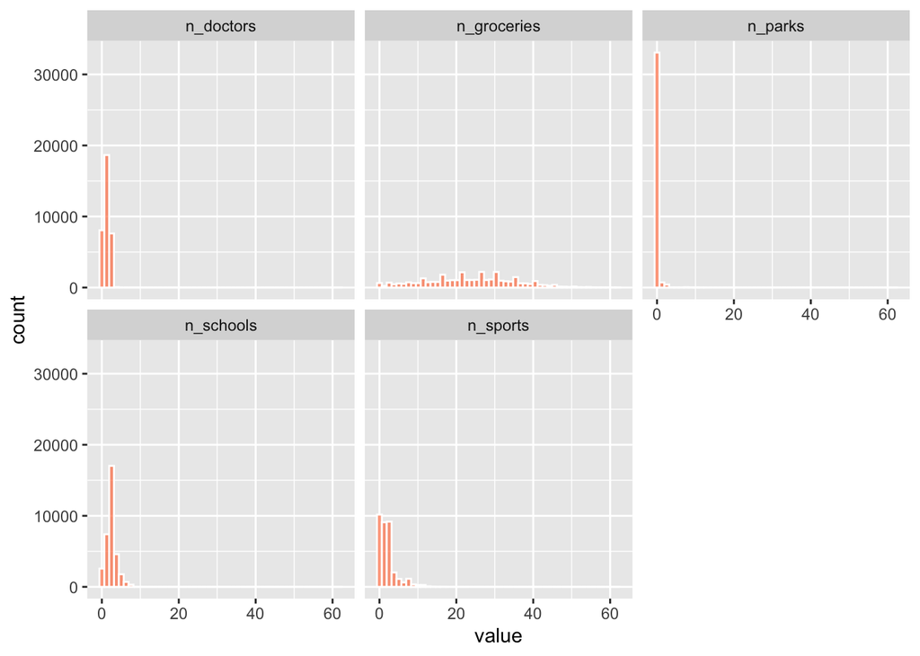

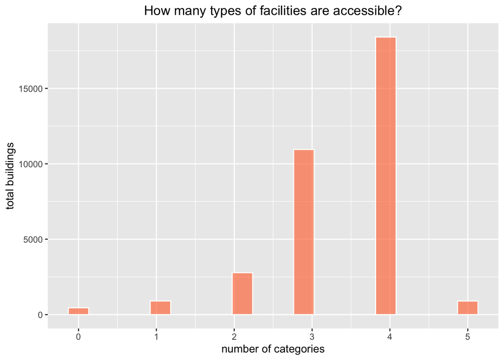

Finally, we aggregate the sum of 5 categories by grid and mapped it. We used inverted palette to represent lowest accessibility with darker colour to attract more attention to them.

```r
grid <-  st_read("data/grid.geojson") %>%
  mutate(grid_id = row_number()) %>%
  st_transform(., 3857)

joined <- joined %>%
  st_transform(., 3857)

output <- joined %>%
  st_join(grid,.) %>%
  group_by(grid_id) %>%
  summarize(mean_n = mean(n_total, na.rm = TRUE))
```

```
## tmap mode set to interactive viewing
```

```
## Scale bar width set to 100 pixels
```

[interactive chart not shown]

The majority of the area have access to at least 4 of out 5 categories. However, it is crucial to pay attention to areas below that levels. It can observed, that there are certain areas with lower characteristics. They are primarily in the New Moscow, a large south-westward territory which was added to the city in 2012, but as the analysis shows still lacks proper social and commercial infrastructure.

However, even some central area lack proper accessibility. Another concentration of darker cells can be observed in eastern parts of the city which have traditionally have lower housing prices. It means poorer Muscovites potentially have worse access to basic needs, thus economic inequality is supported by spatial one.

## Conclusion

This study is set to analyse accessibility of daily services in Moscow using the 15-minute city approach. Five key POI categories were obtained from open data portals to investigate whether Moscow resident can reach to them within walkable distance.

We suggest implementing this study into Moscow policy making process to address the spatial inequality, increase pedestrian accessibility and to overall meet the global goals of sustainable development.